# Seat Position - Corelation

Sushanta Panda

7/12/2019

### Corelation Plot of the Seat Position Data from the Faraway package

##### Plot the Pair Plot

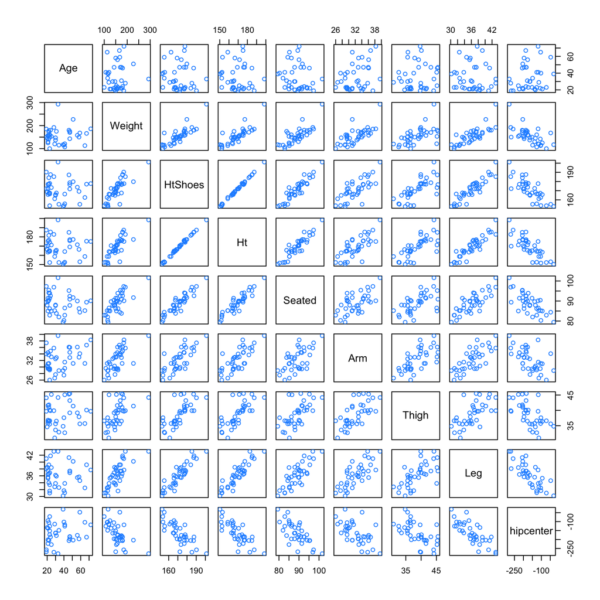

```r
library(faraway)
pairs(seatpos,col = "dodgerblue")
```

##See the Corelation Coefficient

```r
round(cor(seatpos),2)
```

```
##             Age Weight HtShoes    Ht Seated   Arm Thigh   Leg hipcenter
## Age        1.00   0.08   -0.08 -0.09  -0.17  0.36  0.09 -0.04      0.21
## Weight     0.08   1.00    0.83  0.83   0.78  0.70  0.57  0.78     -0.64
## HtShoes   -0.08   0.83    1.00  1.00   0.93  0.75  0.72  0.91     -0.80
## Ht        -0.09   0.83    1.00  1.00   0.93  0.75  0.73  0.91     -0.80
## Seated    -0.17   0.78    0.93  0.93   1.00  0.63  0.61  0.81     -0.73
## Arm        0.36   0.70    0.75  0.75   0.63  1.00  0.67  0.75     -0.59
## Thigh      0.09   0.57    0.72  0.73   0.61  0.67  1.00  0.65     -0.59
## Leg       -0.04   0.78    0.91  0.91   0.81  0.75  0.65  1.00     -0.79
## hipcenter  0.21  -0.64   -0.80 -0.80  -0.73 -0.59 -0.59 -0.79      1.00
```

## Model for all model Predictors

```r
hip_model = lm(hipcenter~., data = seatpos)
summary(hip_model)
```

```
##
## Call:
## lm(formula = hipcenter ~ ., data = seatpos)
##
## Residuals:
##     Min      1Q  Median      3Q     Max
## -73.827 -22.833  -3.678  25.017  62.337
##
## Coefficients:
##              Estimate Std. Error t value Pr(>|t|)
## (Intercept) 436.43213  166.57162   2.620   0.0138 *
## Age           0.77572    0.57033   1.360   0.1843
## Weight        0.02631    0.33097   0.080   0.9372
## HtShoes      -2.69241    9.75304  -0.276   0.7845
## Ht            0.60134   10.12987   0.059   0.9531
## Seated        0.53375    3.76189   0.142   0.8882
## Arm          -1.32807    3.90020  -0.341   0.7359
## Thigh        -1.14312    2.66002  -0.430   0.6706
## Leg          -6.43905    4.71386  -1.366   0.1824
## ---
## Signif. codes:  0 '***' 0.001 '**' 0.01 '*' 0.05 '.' 0.1 ' ' 1
##
## Residual standard error: 37.72 on 29 degrees of freedom
## Multiple R-squared:  0.6866, Adjusted R-squared:  0.6001
## F-statistic:  7.94 on 8 and 29 DF,  p-value: 1.306e-05
```

### Varience Inflation Factor (VIF)

```r
ht_shoes_model = lm(HtShoes~.-hipcenter, data = seatpos)
summary(ht_shoes_model)$r.squared
```

```
## [1] 0.9967472
```

This means the `HtShoes` is well explained by the other predictor in the model. Especially if we see the `pairs` plot, it clearly explained that `Ht` and `HtShoes` predictor is having a linear relationship.

```r
car::vif(hip_model)
```

```
##        Age     Weight    HtShoes         Ht     Seated        Arm
##   1.997931   3.647030 307.429378 333.137832   8.951054   4.496368
##      Thigh        Leg
##   2.762886   6.694291
```

From the above, it sees that `HtShoes` and `Ht` have the high variation inflation factor (vif)

Let’s add some noise to the hipcenter and see what’s the impact of the varience of the parameter

```r
set.seed(1337)
noise = rnorm(n = nrow(seatpos), mean = 0, sd = 5)
hip_model_noise = lm(hipcenter+noise~., data = seatpos)
```

```r
coef(hip_model)
```

```
##  (Intercept)          Age       Weight      HtShoes           Ht
## 436.43212823   0.77571620   0.02631308  -2.69240774   0.60134458
##       Seated          Arm        Thigh          Leg
##   0.53375170  -1.32806864  -1.14311888  -6.43904627
```

```r
coef(hip_model_noise)
```

```
##  (Intercept)          Age       Weight      HtShoes           Ht
## 415.32909380   0.76578240   0.01910958  -2.90377584  -0.12068122
##       Seated          Arm        Thigh          Leg
##   2.03241638  -1.02127944  -0.89034509  -5.61777220
```

From the above it see that the by adding a little noise to the hip center data, also it seems the the parameter sign have reversed for the parameter `Ht`

Let’s plot the fitted value of the model which are predicted from the acutal versis actual + noise

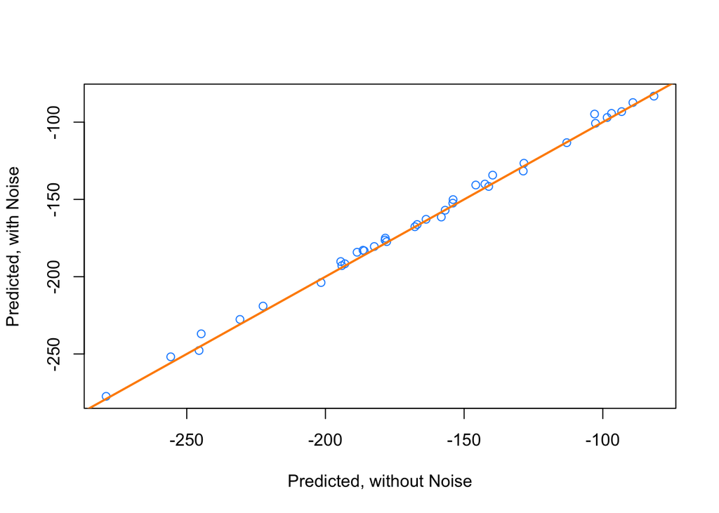

```r
plot(fitted(hip_model),fitted(hip_model_noise),col = "dodgerblue", pch = 1, cex = 1, xlab = "Predicted, without Noise", ylab = "Predicted, with Noise")
abline(0, 1, col = "darkorange",lwd = 2)
```

### Let’s Create a smaller model

```r
hip_model_small = lm(hipcenter~ Age + Arm + Ht, data = seatpos)
hip_model_small
```

```
##
## Call:
## lm(formula = hipcenter ~ Age + Arm + Ht, data = seatpos)
##
## Coefficients:
## (Intercept)          Age          Arm           Ht
##    493.2491       0.7988      -2.9385      -3.4991
```

```r
vif(hip_model_small)
```

```
##      Age      Arm       Ht
## 1.749943 3.996766 3.508693
```

```r
noise = rnorm(nrow(seatpos), mean = 0, sd = 5)
hip_model_small_noise = lm(hipcenter + noise ~ Age + Arm + Ht , data = seatpos)
```

```r
coef(hip_model_small)
```

```
## (Intercept)         Age         Arm          Ht
##  493.249144    0.798761   -2.938464   -3.499061
```

```r
coef(hip_model_small_noise)
```

```
## (Intercept)         Age         Arm          Ht
## 506.9893760   0.8638591  -3.5348617  -3.4768382
```

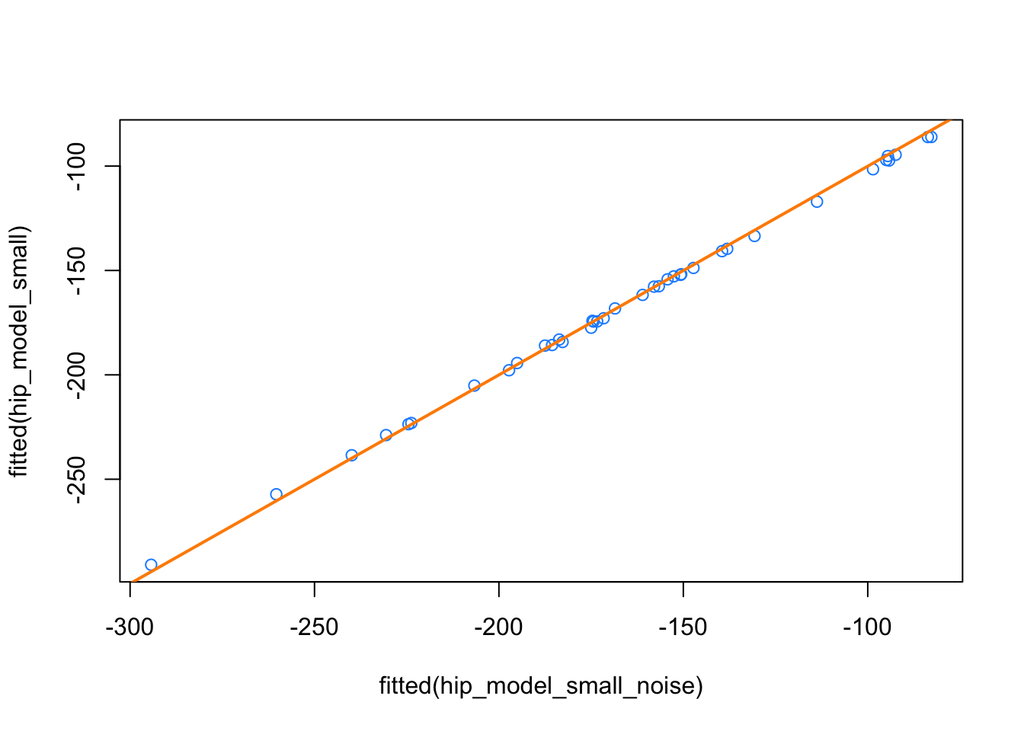

```r
plot(fitted(hip_model_small_noise), fitted(hip_model_small), col = "dodgerblue", pch = 1, cex = 1)
abline (0, 1, col = "darkorange", lty = 1, lwd = 2)
```

```r
anova(hip_model_small,hip_model)
```

```
## Analysis of Variance Table
##
## Model 1: hipcenter ~ Age + Arm + Ht
## Model 2: hipcenter ~ Age + Weight + HtShoes + Ht + Seated + Arm + Thigh +
##     Leg
##   Res.Df   RSS Df Sum of Sq      F Pr(>F)
## 1     34 44354
## 2     29 41262  5    3091.9 0.4346 0.8207
```

Anova F Test shows the smaller model is sufficient and we **failed to reject** the smaller model

```r
hip_model_small = lm(hipcenter~ Age + Arm + Ht, data = seatpos)
hip_model_HtShoes = lm(HtShoes~ Age + Arm + Ht, data = seatpos)

cor(resid(hip_model_small),resid(hip_model_HtShoes))
```

```
## [1] -0.03311061
```

It seems the partial corelation coefficient is very small, hence HtShoes addition is not very useful to the smaller model

#### Now let’s plot a Additive Model

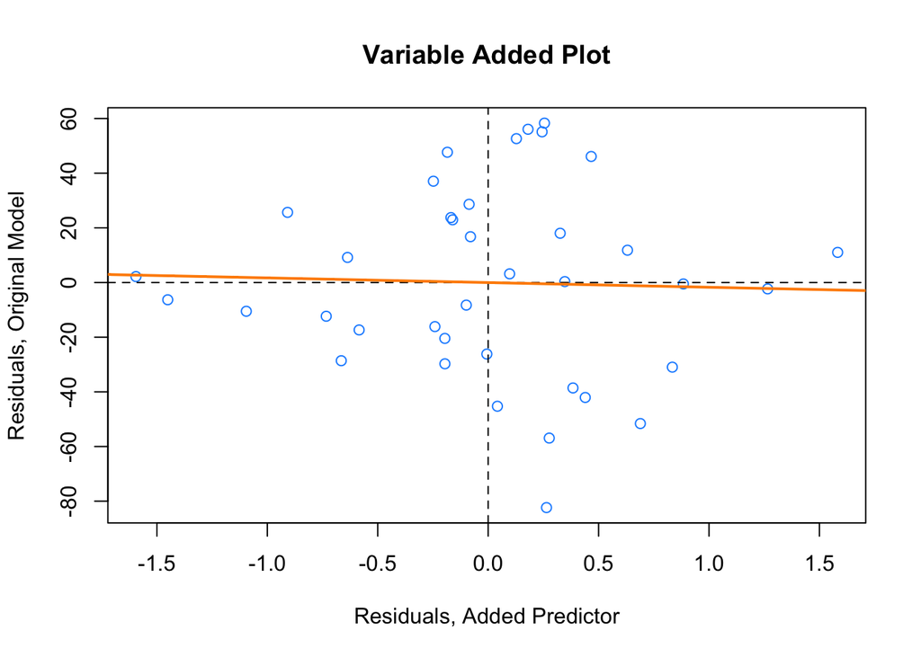

```r
plot(resid(hip_model_HtShoes),resid(hip_model_small), col = "dodgerblue", pch = 1, cex = 1, xlab = "Residuals, Added Predictor", ylab = "Residuals, Original Model", main = "Variable Added Plot")
abline(h = 0, lty = 2)
abline(v = 0, lty = 2)
abline(lm(resid(hip_model_small)~resid(hip_model_HtShoes)), col = "darkorange", lwd = 2, lty =1 )
```